# Lab 07: The Bootstrap

David Murillo

Octuber 19, 2022

# Questions

## Penguin Parametrics CI

- Review the bootstrap and parametric confidence interval materials in the lab walkthrough.
- Calculate a parametric 95% CI for mean bill length (in mm) for the Gentoo penguins in the penguins dataset from package `palmerpenguins` using your SSE function. For this calculation you should use Student’s t-distribution to calculate the critical values
- Q1 (1 pt.): What is the sample size, n? Show the code you used for the calculation and remember to check for missing data.

*Answer: n is 123*

```r
n = sum(!is.na(Gentoo$bill_length_mm))
```

- Q2 (1 pt.): What is the sample standard deviation? Show the code you used for the calculation.

*Answer: the ssd is 3.081857*

```r
sd(Gentoo$bill_length_mm, na.rm = TRUE)
```

```
## [1] 3.081857
```

- Q3 (2 pts.): What are the critical t-values? Show the R code you used for the calculation.

*Answer: the critical t-value is 1.9796*

```r
t_crit = abs(qt(alpha / 2, df = n - 1))
t_crit
```

```
## [1] 1.9796
```

- Q4 (1 pt.): What is the sample standard error? Show the R code you used for the calculation.

```r
SSE = function(x){
  sd(x, na.rm = TRUE )/sqrt(sum(!is.na(x)))
}

SSE(Gentoo$bill_length_mm)
```

```
## [1] 0.2778817
```

- Q5 (2 pts.): Finally, construct the CI and show the R code you used for the calculation.

*Answer: the lower CI is 46.9548 and the upper is 48.0550*

```r
ci_radius <- t_crit * SSE(Gentoo$bill_length_mm)

bill_ci = c(
  lower = mean(Gentoo$bill_length_mm, na.rm = TRUE) - ci_radius,
  upper = mean(Gentoo$bill_length_mm, na.rm = TRUE) + ci_radius)

print(round(bill_ci, 4))
```

```
##   lower   upper
## 46.9548 48.0550
```

## Penguin Bootstrap CI

```
- Review the bootstrap confidence interval materials in the lab walkthrough.
- Calculate a bootstrap 95% CI for mean bill length (in mm) for the Gentoo penguins in penguins dataset from package palmerpenguins.
- Use the boot() function from package boot()
```

- Q6 (1 pt.): What is the CI?

- Q7 (1 pt.): Show the r code you used to call the boot() function.

*Answer:*

```r
library(boot)

boot_mean = function(x, i)
{
  return(mean(x[i], na.rm = TRUE))
}

myboot =
  boot(
    data = Gentoo$bill_length_mm,
    statistic = boot_mean,
    R = 10000)
```

- Q8 (2 pts.): Show the r code you used to calculate the upper and lower 2.5% quantiles.

*Answer:*

```r
quantile(
  myboot$t,
  c(0.025, 0.975))
```

```
##     2.5%    97.5%
## 46.97478 48.05047
```

## Rarefaction Sampler

```
-You’ll be using your rarefaction_sampler() function together with the rare moth abundance data.

-Review the rarefaction curve materials in the lab walkthrough and complete the the rarefaction_sampler() function code.

-Be sure to test out your completed function using the debugging template to make sure it works correctly.

-Calculate a rarefaction curve using 10000 replicate simulations.

-Create a plot of your moth sampling rarefaction curve using the code in the lab walkthrough as a template. Include a 95% confidence envelope, i.e. upper 97.5 and and lower 2.5%.
```

- Q9 (5 pts.): Show your completed rarefaction_sampler() function.

*Answer:*

```r
rm(list = ls())

rarefaction_sampler = function(input_dat, n_iterations)
{
  n_input_rows = nrow(input_dat)

  results_out = matrix(
    nrow = n_iterations,
    ncol = n_input_rows)

  for(i in 1:n_iterations)
  {

    for(j in 1:n_input_rows)
    {
      rows_j = sample(n_input_rows, size = j, replace=TRUE)

      t1 = input_dat[rows_j, ]

      t2 = apply(t1, 2, sum)

      results_out[i, j] = sum(t2 > 0)
    }
  }
  return(results_out)
}
```

- Q10 (1 pt.): What did you find most difficult about building the function?

*Answer: Was a little complicate to know that the n value have to change for the sample size of x, but was a nice exercise*

- Q11 (4 pts.): Show the code you used to perform the simulations and construct the curve.

**Answer:*

```r
moths = read.csv(here("data", "moths.csv"))
rarefact = rarefaction_sampler(moths[,-1], 1000)
head(rarefact)
```

[output not shown]

- Q12 (4 pts.): Include your rarefaction curve plot in your report. Show the R-code you used to create your plot.

*Answer:*

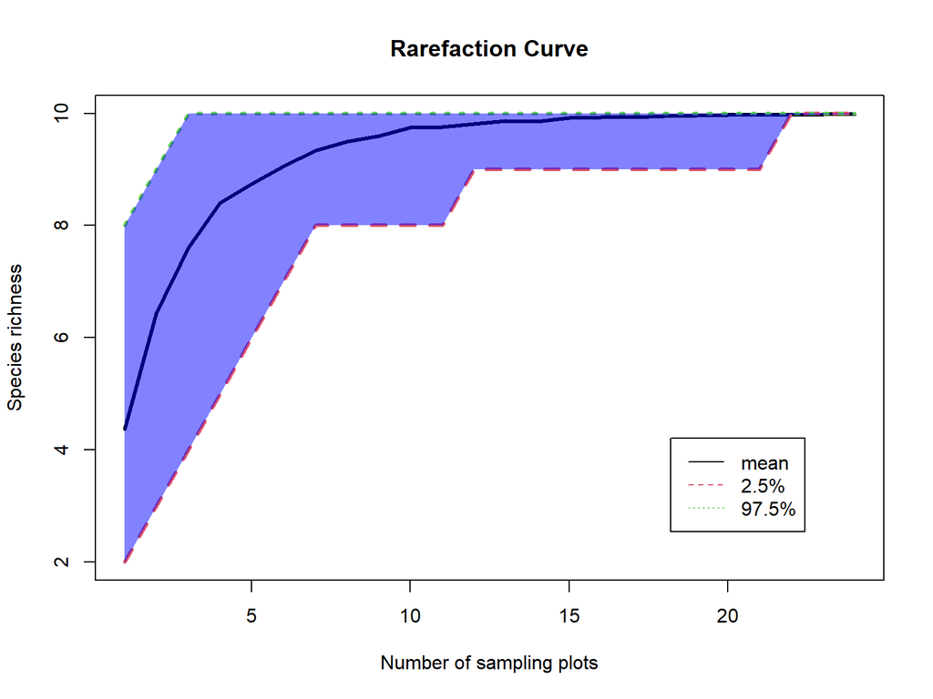

```r
rare_mean = apply(rarefact, 2, mean)
rare_quant = apply(rarefact, 2, quantile, probs=c(0.025, 0.975))
rare = t(rbind(rare_mean, rare_quant))

upper <- rare_quant[2,]
lower <-  rare_quant[1,]

mycol <- rgb(0, 0, 255, max = 255, alpha = 125, names = "blue50")

matplot(
  rare,
  type='l',
  xlab='Number of sampling plots',
  ylab='Species richness',
  main="Rarefaction Curve",
  lwd = c(3,3,3),
  col = c(1,2,3))

legend(
  'bottomright',
  legend=c('mean','2.5%','97.5%'),
  lty=c(1,2,3),col=c(1,2,3), inset=c(.1,.1) )

polygon(c(1:24, rev(1:24)), c(upper, rev(rare_mean)), col = mycol,
        border = NA)

polygon(c(1:24, rev(1:24)), c(lower, rev(rare_mean)), col = mycol,
         border = NA)
```

- Q13 (2 pts.): About how many sites should you visit if you want to see all of the moth species? Explain your reasoning using your rarefaction curve figure.